# Benchmark rsofun tag v2.0

## Description

This assumes that the model is already calibrated (calibratable parameters are prescribed).

Note: For simulations used in Stocker et al. (2020), forcing data was written to files and read by Fortran. With the updated rsofun model, this is passed through R, using an object formatted like `rsofun::df_drivers`.

## Load data

Load drivers data frame (created by `prepare_inputs_FLUXNET2015_ensemble.Rmd`).

```r
load("~/data/rsofun_benchmarking/df_drivers_fluxnet2015.Rdata")
```

There seem to be some leap year dates which create problems for rsofun. Drop Feb. 29 dates.

```r
df_drivers_fluxnet2015 <- df_drivers_fluxnet2015 %>%
  dplyr::select(sitename, forcing) %>%
  unnest(forcing) %>%
  dplyr::filter(!(month(date)==2 & mday(date)==29)) %>%
  group_by(sitename) %>%
  nest() %>%
  rename(forcing = data) %>%
  right_join(
    df_drivers_fluxnet2015 %>%
      dplyr::select(-forcing),
    by = "sitename"
  ) %>%
  ungroup()

save(df_drivers_fluxnet2015, file = "~/data/rsofun_benchmarking/df_drivers_fluxnet2015.Rdata")
```

## Calibrate model

Define calibration sites.

```r
flue_sites <- readr::read_csv( "~/data/flue/flue_stocker18nphyt.csv" ) %>%
              dplyr::filter( !is.na(cluster) ) %>%
              distinct(site) %>%
              pull(site)
calibsites <- siteinfo_fluxnet2015 %>%
  dplyr::filter(!(sitename %in% c("DE-Akm", "IT-Ro1"))) %>%  # excluded because fapar data could not be downloaded (WEIRD)
  # dplyr::filter(!(sitename %in% c("AU-Wom"))) %>%  # excluded because no GPP data was found in FLUXNET file
  dplyr::filter(sitename != "FI-Sod") %>%  # excluded because some temperature data is missing
  dplyr::filter( c4 %in% c(FALSE, NA) & classid != "CRO" & classid != "WET" ) %>%
  dplyr::filter( sitename %in% flue_sites ) %>%
  pull(sitename)
```

Define calibration settings.

```r
settings_calib <- list(
  method              = "gensa",
  targetvars          = c("gpp"),
  timescale           = list( gpp = "d" ),
  maxit               = 5,
  sitenames           = calibsites,
  metric              = "rmse",
  dir_results         = "./",
  name                = "FULL",
  par                 = list( kphio       = list( lower=0.03, upper=0.1, init= 0.05 ),
                              soilm_par_a = list( lower=0.0,  upper=1.0, init=0.0 ),
                              soilm_par_b = list( lower=0.0,  upper=1.5, init=0.6 ) )
 )
```

Use the ingestr package once again, now for collecting calibration target data. I.e., GPP based on the nighttime flux decomposition method.

```r
settings_ingestr_fluxnet <- list(
  dir_hh = "~/data/FLUXNET-2015_Tier1/20191024/HH/",
  getswc = FALSE,
  filter_ntdt = TRUE,
  threshold_GPP = 0.8,
  remove_neg = FALSE
  )

filn <- "~/data/rsofun_benchmarking/ddf_fluxnet_gpp.Rdata"
if (!file.exists(filn)){
  ddf_fluxnet_gpp <- ingestr::ingest(
    siteinfo = siteinfo_fluxnet2015 %>%
      dplyr::filter(sitename %in% calibsites),
    source    = "fluxnet",
    getvars = list(gpp = "GPP_NT_VUT_REF",
                   gpp_unc = "GPP_NT_VUT_SE"),
    dir = "~/data/FLUXNET-2015_Tier1/20191024/DD/",
    settings = settings_ingestr_fluxnet,
    timescale = "d"
    )
  save(ddf_fluxnet_gpp, file = filn)
} else {
  load(filn)
}
```

Calibrate the model.

```r
set.seed(1982)
settings_calib <- calib_sofun(
  df_drivers = dplyr::filter(df_drivers_fluxnet2015, sitename %in% calibsites),  # use only one site
  ddf_obs = ddf_fluxnet_gpp,
  settings = settings_calib
  )
```

```
##       kphio soilm_par_a soilm_par_b
##  0.09423773  0.33349283  1.45602286
## [1] "writing output from GenSA function to .//out_gensa_FULL.Rdata"
## [1] "writing calibrated parameters to .//params_opt_FULL.csv"
```

The calibrated parameters are returned by `calib_sofun()` as part of the list:

```r
print(settings_calib$par_opt)
```

```
##       kphio soilm_par_a soilm_par_b
##  0.09423773  0.33349283  1.45602286
```

```r
save(settings_calib, file = "./settings_calib.Rdata")
```

Update model parameters.

```r
params_modl <- list(
    kphio           = 0.05,
    soilm_par_a     = 1.0,
    soilm_par_b     = 0.0,
    vpdstress_par_a = 9999,
    vpdstress_par_b = 9999,
    vpdstress_par_m = 9999
    )
params_modl <- update_params(params_modl, settings_calib)
```

## Run model

```r
df_output <- runread_pmodel_f(
     df_drivers_fluxnet2015,
     params_modl = params_modl,
     makecheck = TRUE,
     parallel = FALSE
     )
```

## Run evaluation

Do evaluation only for sites where simulation was run.

```r
evalsites <- df_output %>%
  mutate(ntsteps = purrr::map_dbl(data, ~nrow(.))) %>%
  dplyr::filter(ntsteps > 0) %>%
  pull(sitename)
```

Load standard benchmarking file with observational data for evaluation.

```r
load("~/data/rsofun_benchmarking/obs_eval_fluxnet2015.Rdata")
```

Define evaluation settings.

```r
settings_eval <- list(
  benchmark = list( gpp = c("fluxnet") ),
  sitenames = evalsites,
  agg       = 8  # An integer specifying the number of days used to define the width of bins for daily data aggregated to several days
  )
```

And finally run the evaluation.

```r
out_eval <- eval_sofun(
  df_output,
  settings_eval,
  settings_sims,
  obs_eval = obs_eval,
  overwrite = TRUE,
  light = FALSE
  )
```

[output not shown]

## Evaluation results

### Metrics table

```r
out_eval$gpp$fluxnet$metrics %>%
  bind_rows(.id = "Level") %>%
  kable
```

| Level | rsq | rmse | slope | bias | nvals |
| --- | --- | --- | --- | --- | --- |
| daily_pooled | 0.6642757 | 2.319010 | 0.9000923 | 0.0512379 | 237777 |
| xdaily_pooled | 0.7279964 | 2.013046 | 0.9954593 | 0.0589184 | 33152 |
| annual_pooled | 0.6975060 | 387.264749 | 1.1021103 | -0.1161397 | 598 |
| monthly_pooled | 0.7549710 | 1.821658 | 1.0311189 | -0.0579248 | 7428 |
| spatial | 0.7050864 | 409.071881 | 1.0441503 | -17.7978575 | 109 |
| anomalies_annual | 0.0740318 | 176.703855 | 0.4212289 | -3.5712779 | 598 |
| meandoy | 0.7223901 | 1.861926 | 0.9815391 | 0.1352034 | 42844 |
| anomalies_daily | 0.2617192 | 1.650105 | 0.4115856 | -0.0356838 | 237603 |
| meanxoy | 0.7497625 | 1.737801 | 1.0088096 | 0.1177065 | 5528 |
| anomalies_xdaily | 0.1422624 | 1.247193 | 0.3847555 | -0.0042873 | 33152 |

### Visualisations

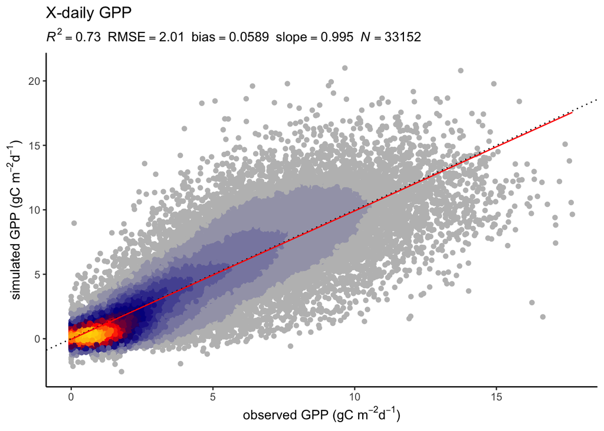

```r
out_eval$gpp$fluxnet$plot$gg_modobs_xdaily
```

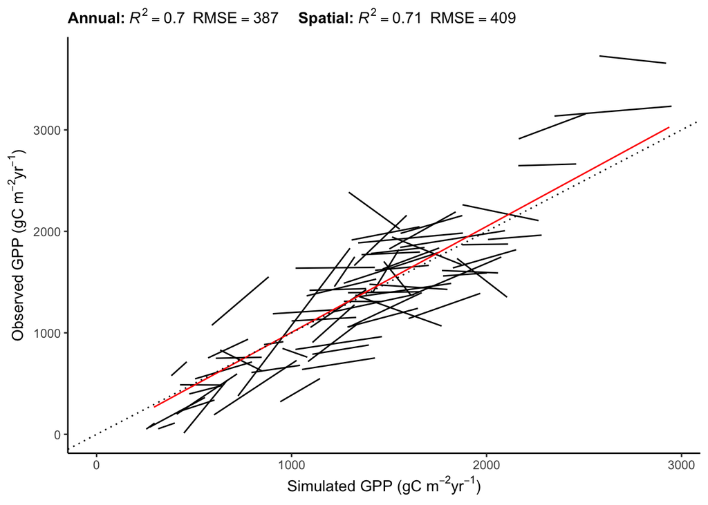

```r
out_eval$gpp$fluxnet$plot$gg_modobs_spatial_annual
```

## Appendix

### Site list

```r
siteinfo_fluxnet2015 %>%
  dplyr::filter(sitename %in% evalsites) %>%
  kable()
```

| sitename | lon | lat | elv | year_start | year_end | classid | c4 | whc | koeppen_code | igbp_land_use | plant_functional_type |
| --- | --- | --- | --- | --- | --- | --- | --- | --- | --- | --- | --- |
| AR-SLu | -66.4598 | -33.4648 | 499.0 | 2009 | 2011 | MF | FALSE | 268.42401 | Bwk | NA | NA |
| AR-Vir | -56.1886 | -28.2395 | 97.0 | 2009 | 2012 | ENF | FALSE | 302.42755 | Csb | NA | NA |
| AT-Neu | 11.3175 | 47.1167 | 970.0 | 2002 | 2012 | GRA | FALSE | 270.08563 | Dfc | Mixed Forests | Evergreen Broadleaf Trees |
| AU-Ade | 131.1178 | -13.0769 | 81.0 | 2007 | 2009 | WSA | FALSE | 269.21866 | Aw | Savannas | Grass |
| AU-ASM | 133.2490 | -22.2830 | 606.0 | 2010 | 2013 | ENF | FALSE | 214.58427 | BSh | Open Shrublands | Shrub |
| AU-Cpr | 140.5891 | -34.0021 | 57.0 | 2010 | 2014 | SAV | FALSE | 217.31125 | BSk | Closed Shrublands | Shrub |
| AU-Cum | 150.7225 | -33.6133 | 28.0 | 2012 | 2014 | EBF | FALSE | 310.86740 | Cfa | Woody Savannas | Evergreen Broadleaf Trees |
| AU-DaP | 131.3181 | -14.0633 | 102.0 | 2007 | 2013 | GRA | FALSE | 294.63034 | Aw | Savannas | Grass |
| AU-DaS | 131.3881 | -14.1593 | 98.0 | 2008 | 2014 | SAV | FALSE | 249.25092 | Aw | Savannas | Grass |
| AU-Dry | 132.3706 | -15.2588 | 172.0 | 2008 | 2014 | SAV | FALSE | 239.15613 | Aw | Savannas | Grass |
| AU-Emr | 148.4746 | -23.8587 | 183.0 | 2011 | 2013 | GRA | FALSE | 212.93277 | Bwk | NA | NA |
| AU-Gin | 115.7138 | -31.3764 | 51.0 | 2011 | 2014 | WSA | FALSE | 194.44785 | Csa | Woody Savannas | Shrub |
| AU-GWW | 120.6541 | -30.1913 | 452.0 | 2013 | 2014 | SAV | FALSE | 183.37975 | Bwk | NA | NA |
| AU-Lox | 140.6551 | -34.4704 | 48.0 | 2008 | 2009 | DBF | FALSE | 248.41380 | Bsh | NA | NA |
| AU-RDF | 132.4776 | -14.5636 | 181.0 | 2011 | 2013 | WSA | FALSE | 290.04077 | Bwh | NA | NA |
| AU-Rig | 145.5759 | -36.6499 | 153.0 | 2011 | 2014 | GRA | FALSE | 251.43498 | Cfb | Croplands | Cereal crop |
| AU-Rob | 145.6301 | -17.1175 | 772.0 | 2014 | 2014 | EBF | FALSE | 265.16736 | Csb | NA | NA |
| AU-Stp | 133.3502 | -17.1507 | 227.0 | 2008 | 2014 | GRA | FALSE | 283.41589 | BSh | Grasslands | Grass |
| AU-TTE | 133.6400 | -22.2870 | 552.0 | 2012 | 2013 | OSH | FALSE | 217.10576 | BWh | Open Shrublands | Shrub |
| AU-Tum | 148.1517 | -35.6566 | 932.0 | 2001 | 2014 | EBF | FALSE | 248.48276 | Cfb | Evergreen Broadleaf Forest | Evergreen Broadleaf Trees |
| AU-Wac | 145.1878 | -37.4259 | 562.0 | 2005 | 2008 | EBF | FALSE | 163.75224 | Cfb | Evergreen Broadleaf Forest | Evergreen Broadleaf Trees |
| AU-Whr | 145.0294 | -36.6732 | 152.0 | 2011 | 2014 | EBF | FALSE | 271.49738 | Cfb | Woody Savannas | Shrub |
| AU-Wom | 144.0944 | -37.4222 | 705.0 | 2010 | 2012 | EBF | FALSE | 189.57100 | Cfb | Evergreen Broadleaf Forest | Evergreen Broadleaf Trees |
| AU-Ync | 146.2907 | -34.9893 | 125.0 | 2012 | 2014 | GRA | FALSE | 199.15875 | BSk | Croplands | Cereal crop |
| BE-Bra | 4.5206 | 51.3092 | 16.0 | 1996 | 2014 | MF | FALSE | 85.68380 | Cfb | Mixed Forests | Deciduous Broadleaf Trees |
| BE-Vie | 5.9981 | 50.3051 | 493.0 | 1996 | 2014 | MF | FALSE | 312.76520 | Cfb | Mixed Forests | Deciduous Broadleaf Trees |
| BR-Sa3 | -54.9714 | -3.0180 | 100.0 | 2000 | 2004 | EBF | FALSE | 207.06451 | Am | Evergreen Broadleaf Forest | Evergreen Broadleaf Trees |
| CA-Man | -98.4808 | 55.8796 | 259.0 | 1994 | 2008 | ENF | FALSE | 52.67784 | Dfc | Evergreen Needleleaf Forest | Evergreen Needleleaf Trees |
| CA-NS1 | -98.4839 | 55.8792 | 260.0 | 2001 | 2005 | ENF | FALSE | 50.25988 | Dfc | Evergreen Needleleaf Forest | Evergreen Needleleaf Trees |
| CA-NS2 | -98.5247 | 55.9058 | 260.0 | 2001 | 2005 | ENF | FALSE | 59.02733 | Dfc | Evergreen Needleleaf Forest | Evergreen Needleleaf Trees |

[output cut: 99 more lines]